# 與 AI 對話打造 GLM 分析 Skill

廣義線性模型方法論與 Skill 生成過程

作者

R26144063李姿慧

# 1 方法論：廣義線性模型

## 1.1 為什麼需要廣義線性模型？

- 一般線性迴歸通常假設：**給定解釋變數下**，誤差服從常態分佈、變異數固定，條件平均數可以是任意實數
- 實務上很多反應變數不符合這些條件：
  - **二元資料**：是否就醫、是否違約
  - **計數資料**：一年看診次數、事故件數
  - **正值右偏資料**：醫療費用、等候時間
- GLM（Nelder & Wedderburn, 1972）提供統一的架構，依反應變數的型態選擇適當的分佈與連結函數

## 1.2 GLM 的三個組成

1. **隨機成分**：給定 $X$ 時，$Y_i$ 服從指數族分佈（常態、二項、Poisson、Gamma 等）
2. **系統成分**：線性預測式 $\eta_i = \beta_0 + \beta_1 x_{i1} + \cdots + \beta_p x_{ip}$
3. **連結函數**：$g(\cdot)$ 把條件平均數 $\mu_i = E(Y_i \mid X_i)$ 和線性預測式連起來

$$g(\mu_i) = \eta_i = \mathbf{x}_i^{\top}\boldsymbol{\beta}$$

## 1.3 一般線性迴歸 vs. GLM

**一般線性迴歸**

$$E(Y_i \mid X_i) = \mathbf{x}_i^{\top}\boldsymbol{\beta}$$

- 條件平均數直接是解釋變數的線性函數
- 通常搭配常態誤差與固定變異數

**廣義線性模型**

$$g\{E(Y_i \mid X_i)\} = \mathbf{x}_i^{\top}\boldsymbol{\beta}$$

- 透過連結函數，讓**轉換後的**條件平均數是線性函數
- 依反應變數選擇分佈家族，變異數可以隨平均數改變

一般線性迴歸是 GLM 的特例：常態分佈 + identity link

## 1.4 常見分佈家族與係數解讀

| 反應變數 | 分佈家族 | 連結函數 | 係數解讀 |
| --- | --- | --- | --- |
| 連續、對稱 | Gaussian | identity | $\beta_j$：其他變數固定時，$X_j$ 增加一單位，條件平均數的變化量 |
| 二元 0/1、成功數／試驗數 | Binomial | logit | $\exp(\beta_j)$：勝算比（OR），不是成功機率的倍數 |
| 非負整數計數 | Poisson | log | $\exp(\beta_j)$：條件平均數比；有適當的 exposure offset 時，可解釋為發生率比（RR） |
| 連續正值右偏 | Gamma | log | $\exp(\beta_j)$：條件平均數的倍數效果 |

- 係數的意義由**連結函數**決定：identity 是加法效果，log 與 logit 取指數後是乘法效果
- 計數資料變異遠大於平均數（過度離散）時，常見的延伸是**負二項迴歸**，它是有完整概似函數的模型；quasi-Poisson 只調整變異數設定，不是完整的機率分佈

## 1.5 模型配適與診斷

GLM 的適用性取決於分佈家族、連結函數、平均數結構及資料相依性等假設是否合理。依 $Y$ 的型態選好 family 和 link **只是起點**，配適後仍要檢查：

- 殘差型態、過度離散，以及零值比例是否和模型預期相符
- 零值多不一定代表零膨脹，也可能來自平均數設定不當或未建模的異質性，應先檢查原模型
- 發現異常時，回頭檢查平均數結構、分佈家族與模型設定

模型診斷檢查的是「假設與配適是否合理」。

# 2 與 AI 對話生成 Skill

## 2.1 什麼是 Skill？

- 一個資料夾，核心是 **SKILL.md**：把「做一件事的標準流程」寫成 AI 會反覆遵循的說明書
- `description` 決定 AI **什麼時候**自動啟用
- 一次寫好，之後每次分析的流程與規範都一致

```
glm-analysis/
├── SKILL.md                         四階段分析流程
├── references/                      需要時才載入的專業知識
│   ├── family-link-selection.md     依反應變數型態選擇 family 與 link
│   ├── diagnostics-checklist.md     模型診斷清單與判讀注意事項
│   ├── model-building-and-validation.md  研究目的、模型比較、診斷與預測表現
│   └── literature.md               各方法對應的參考文獻（已查證）與引用鍵
└── assets/
    ├── report_template.qmd          Quarto 報告範本
    └── references.bib               報告用的 BibTeX 文獻檔（與 literature.md 一致）
```

## 2.2 整個過程一覽

| 階段 | 我做了什麼 | Skill 因此改變 |
| --- | --- | --- |
| 建立骨架 | 問概念、下任務、寫出四步驟流程 | 四階段架構：EDA → 適合性 → 配適 → 診斷 |
| 第一版 | 讓 AI 自己實測 | 修好環境問題後打包 |
| 使用中修正 | 先列變數、確認 X / Y | 不再自己猜反應變數 |
|  | 改用我的 Quarto 範本 | 報告格式符合我的習慣 |
|  | 範本錯誤修正、程式碼輸出限制、資料檢查機制 | 對話更乾淨，資料錯誤會被攔下 |
|  | 改用勾選框提問、輸出最後再選 | 互動不會被誤會已結束 |
|  | 要求 AI 實際測試 | 確認流程與敘述一致 |
|  | 預測新資料用已訓練好的模型 | 不重新切分、不重新訓練 |
|  | 刪除 Word，預設輸出 PDF | 報告格式更單純 |
|  | 連續變數只用線性項 | 不一開始配適二次方、樣條 |
|  | 要求先看圖再描述 | 圖形結論有依據 |
| 發布 | 放上 GitHub、說明執行環境 | 同學知道怎麼安裝與使用 |

## 2.3 第 1 步：先問概念

**我說**

如果寫一個skill

- AI 先讀取內建的 **skill-creator** 說明
- 解釋四個步驟：**確定意圖 → 撰寫 SKILL.md → 測試迭代 → 打包**
- 反問：這個 Skill 要做什麼？什麼請求應該觸發？輸出長什麼樣子？

先讓 AI 說明框架，我才知道接下來要提供哪些資訊

## 2.4 第 2 步：下達任務，回答 AI 的提問

**我說**

利用skill-creator幫我打造一個 可以進行廣義線性模型分析的 skill

AI 沒有直接動手，先用選擇題問用途、GLM 家族、輸出形式。用途這題我**沒有選選項**，而是自己寫出流程：

**我的回答**

1. 先進行 探索性資料分析 2. 確定這個資料適合進行廣義線性分析 3.開始進行統計分析 (根據反映變數選擇link function) 4.進行模型診斷或評估 先前分析適不適當 每個步驟都要逐步呈現、完整解釋

這四句話直接成為 Skill 的**四階段骨架**

## 2.5 第 3 步：AI 寫出第一版並自己實測

- SKILL.md 寫入四階段流程，專業細節拆到 references（決策樹、診斷清單）
- AI 用模擬資料跑完整份報告範本，找到三個問題並寫回 Skill：

| 發現的問題 | 修正 |
| --- | --- |
| 環境中沒有 R | 加入安裝指令清單 |
| 中文程式碼 parse error（locale 為 C） | 執行時加 `LC_ALL=C.UTF-8` |
| `check_model()` 畫不出圖 | 改用 base R 的 `plot(model)` |

## 2.6 修正 1：先確認變數，不要自己猜

- 第一版拿到資料就直接開始分析，AI 會**自己猜**哪個是反應變數
- 我要求：讀入資料後先列出全部變數，再讓我確認 Y 和 X
- Skill 新增 **Stage 1-0**：
  - 列出變數名稱、型態、相異值個數、遺漏值、範例值
  - 使用者沒說明就必須詢問，提供建議但不可自行決定
  - 確認後寫成一句「反應變數：○○；解釋變數：△△」，後續都以此為準

## 2.7 修正 2：改用我自己的 Quarto 範本

- 原本的報告範本是 R Markdown
- 我把自己慣用的 Quarto 範本給 AI，要求報告照它的格式產出
- AI 改寫成 `report_template.qmd`，一份檔案可輸出 PDF / HTML（後來刪除 Word）
  - 保留 xelatex、中文字型、目錄、章節編號等設定
  - 圖表用 `@fig-` / `@tbl-` 自動編號、交叉引用
- AI 也指出範本中的小問題請我確認，例如 YAML 的 `%` 不是註解

## 2.8 修正 3：完善 AI 的互動與分析流程

**我說**

1.範本有一個錯誤……`showtext::font_add()`，但這個函式其實屬於 `sysfonts` 套件，所以第一次渲染直接報錯……

2. 如果在對話裡輸出，我沒叫你給我R CODE不用給我。

3. 在對話裡做EDA的時候， 做完以後先讓使用者確認資料是否有問題(尤其最大最小值) 可能TYPO或奇怪的數值， 使用者說資料沒問題就繼續下一步。

- 修正 `sysfonts::font_add()`：AI 的測試環境沒有這個套件，所以沒測到，**要靠實際使用才會發現**
- 對話中只呈現結果與解釋，程式碼留在背景和報告檔
- 新增 **資料檢查關卡**：列出最大最小值、各類別個數，標出可疑值，我確認後才進入下一階段

## 2.9 修正 4：只先配一個模型

**我說**

模型的部分，一開始只提供一個模型就好， 不用一開始就列很多候選模型，除非使用者有要求。

- 前一輪修正後，AI 會一次列出一堆候選模型，結果反而難讀
- 新流程：

  **m1** → 診斷 → 有問題才提出 **m2** → 比較 m1 與 m2 → 確認最終模型
- 沒有發現問題，m1 就是最終模型；使用者要求時才比較多個模型

## 2.10 修正 5：讓互動更順暢

**我說**

如果需要使用者進行選擇請進行check box， 不要完整停下需要使用者在對話框回應，會讓人誤會已經結束了，另外不要預設在對話裡進行分析， 在問完使用者所有問題以後讓使用這進行決定要在對話還是製作quarto。

- 所有需要使用者決定的地方都改用**勾選框**，同一階段的問題一次問完
- 輸出形式不再預設，最後一題讓使用者選：
  - 對話中逐步呈現
  - Quarto 報告（PDF / HTML / Word）

這是從**使用者體驗**出發的修正，只有實際用過才會發現

## 2.11 修正 6：要求 AI 實際測試

**我說**

你可以實際跑一個資料測試， 有無符合這個skill應該要有的流程與邏輯與敘述。

- AI 用模擬資料，從頭照 Skill 的流程跑一次，逐條對照規則
- 檢查「寫在 Skill 裡的流程」和「實際執行的結果」是否一致
- 測試中也抓到問題：收入變數取 log 的理由不足，不符合 Skill 自己的規則

**改完規則之後要再跑一次，才知道規則有沒有真的被遵守**

## 2.12 修正 7：增加「預測新資料」

- 原本版本讓AI預測新資料，他會重新訓練新模型，而不是使用先前已經訓練好的模型

**我說**

如果解釋關聯以後使用者要拿最終模型來預測新資料的話也可以，不用重新繞回重TRAIN模型。

- 分析完成後，直接用最終模型 `predict(model, newdata)`，**不重新切分、不重新訓練**
- Skill 會說明：沒做過樣本外驗證時預測表現未知；新資料超出原樣本範圍屬於外推

## 2.13 修正 8：輸出格式更單純

**我說**

刪除輸出格式有docx，預設quarto輸出pdf 要把code打開，保留html目前可以摺疊程式碼。

- 刪除 Word 輸出，Quarto 報告只保留 PDF 與 HTML
- 選 Quarto 報告又沒指定格式時，**預設輸出 PDF**，並顯示程式碼（`echo: true`）
- HTML 保留程式碼摺疊（`code-fold: true`），讀者需要時再展開

## 2.14 修正 9：解釋變數先用一次項

**我說**

我不喜歡一開始模型就配置 解釋變數是二次方..等 ，除非後續模型不好， 才可以在報告裡延伸討論說之後可以改非線性，請刪掉skill這個部分以及後續相關檢定

- 連續解釋變數**預設以一次項納入**，不一開始配適二次方、多項式或樣條
- 刪除挑選函數形式的分組趨勢圖與相關檢定
- 診斷時殘差對某個變數呈現曲線，**不自行加入非線性項**，只在報告中描述，列為「後續可考慮改用非線性形式」的延伸討論
- 模型簡單、係數好解釋，也避免嘗試很多形式再挑最好看的

## 2.15 修正 10：先看圖，再描述

**我說**

寫模型診斷、需要任何對圖片進行描述或結論前 必須要先查看圖長怎樣，不可以憑感覺、印象就下結論。

- 新增硬性規定：描述任何圖（EDA 圖、殘差圖、Q-Q 圖、報告轉出後的圖）之前，**必須先存成圖片並實際查看**
- 不可以憑圖形的一般樣貌或程式碼的預期結果下結論，例如沒看圖就寫「殘差大致隨機分布」
- 看不到圖時明說「無法檢視圖形」，改以數值診斷為主
- 描述要具體，指出哪個區域、哪幾個點

## 2.16 發布：放上 GitHub

- 打包成 `glm-analysis.skill`
- 放到 GitHub：`SC3-GLM_Analysis`
- 請 AI 撰寫 README：
  - Skill 會做什麼
  - 如何和它對話、它會問你哪些問題
  - 輸出形式的選擇
  - 安裝方式
- 範例資料 `nhanes_data.csv` 與這份說明文件也放在 GitHub

## 2.17 現在的 Skill 怎麼運作？

```
flowchart TD
    A["列出變數<br>勾選確認 X / Y"] --> B["確認變數的時間順序"]
    B --> C["EDA"]
    C --> D["資料檢查關卡<br>確認最大最小值、typo"]
    D -->|"有問題"| D1["修正或排除後重新檢查"]
    D1 --> D
    D -->|"沒問題"| E["適合性評估<br>獨立性、offset、完全分離"]
    E --> F["選擇 family / link<br>連續變數以線性項放入"]
    F --> G["配適 m1<br>解釋係數與信賴區間"]
    G --> H["模型診斷<br>殘差、過度離散、共線性、適合度、零值"]
    H -->|"有問題"| I["提出 m2 並比較"]
    H -->|"沒問題"| K
    I --> K["結論與最終模型一致"]
    K --> N["輸出形式<br>對話 或 Quarto（預設 pdf，或 html）"]
    N --> O["結尾提醒一句：<br>可提供新資料做預測"]
    O -.->|"使用者提供新資料"| L["直接用最終模型 predict newdata<br>不重新切分、不重新訓練"]
```

需要決定的地方都會用勾選框詢問。輸出形式實際上是在開始分析前所有問題的最後一題，圖中放在最後只是方便閱讀。

## 2.18 與 AI 協作的心得

1. **先問概念，再下任務**：了解框架才知道要提供什麼
2. **需求寫到「流程」層級**：我寫的四個步驟就是 Skill 的骨架
3. **實際使用才會發現問題**：字型錯誤、程式碼太多、提問方式讓人誤會
4. **改完要再測**：規則寫得對，不代表執行得對
5. **不確定就問正反理由**：先請 AI 給觀點，再自己決定

## 2.19 總結

- AI 負責**撰寫、執行、測試**
- 我負責**定義流程、判斷對錯、決定範圍**
- Skill 是在「使用 → 發現問題 → 修正 → 再測試」的循環中逐步完成的

# 3 實例：如何在 Claude 使用這個 Skill

## 3.1 步驟 1：安裝 Skill

**Claude.ai（網頁或桌面版）**

1. 到 GitHub `SC3-GLM_Analysis` 的 Releases 下載 `glm-analysis.skill` （或把 `glm-analysis` 資料夾壓縮成 zip）
2. 在 Claude 的設定中找到 **Skills**，上傳這個檔案
3. 上傳後，新的對話就能使用這個 Skill

**Claude Code**

- 把整個 `glm-analysis` 資料夾放到 `~/.claude/skills/`
- 只在某個專案使用時，放在該專案的 `.claude/skills/`

放好之後，`SKILL.md` 的路徑應該是 `~/.claude/skills/glm-analysis/SKILL.md`。放的是裡面的 `glm-analysis` 資料夾，不是整個 GitHub 專案資料夾，否則會多包一層，Claude Code 找不到。

## 3.2 補充：Claude 如何執行 R？

Skill 本身只是**文字指示**，不含 R，也不會執行程式。

真正執行 R 的是 Claude 的**程式執行環境**：

| 角色 | 是什麼 | 比喻 |
| --- | --- | --- |
| Skill | 分析流程的指示 | 食譜 |
| 執行環境 | 能下指令、跑程式的地方 | 廚房 |
| R（`Rscript`） | 實際做統計運算 | 爐子 |

## 3.3 R 在哪裡執行？

|  | Claude.ai（網頁 / 桌面版） | Claude Code |
| --- | --- | --- |
| 執行位置 | Anthropic 雲端 Linux 容器 | 你自己的電腦 |
| R 從哪來 | Claude 依 skill 指示自動安裝 | 使用本機已安裝的 R |
| 前提 | 開啟程式執行功能 | 本機需先裝好 R 與套件 |

## 3.4 Claude.ai 執行 R 的流程

```
flowchart LR
  A["讀取 SKILL.md"] --> B{"容器裡<br>有沒有 R？"}
  B -->|"沒有"| C["apt-get 安裝<br>R 與套件"]
  B -->|"有"| D["寫 R 腳本<br>執行 Rscript"]
  C --> D
  D --> E["回傳表格<br>圖檔、報告"]
```

- 每開一次新對話，容器就會重置，之前裝的套件不會保留，所以 skill 規定**每次先檢查**；同一場對話內則會保留
- 執行時加 `LC_ALL=C.UTF-8`，避免中文造成錯誤

## 3.5 步驟 2：開始對話

- 用自然語言描述需求，並附上資料（csv、xlsx，或讀資料的 R 程式碼）
- 不一定要說出「GLM」，提到迴歸、計數、0/1 資料等需求就會自動啟用
- 也可以用 `/glm-analysis` 直接指定這個 Skill

*有三種工作模式可以選擇*

| 工作模式 | 說明 |
| --- | --- |
| 完整分析 | 從 EDA 一路做到診斷，每個階段都逐步解釋 |
| 指定步驟 | 只做指定的階段，例如「只做診斷」 |
| 接續分析 | 已有部分結果，從中間接手 |

**對話範例**

/glm-analysis 使用這個資料進行分析（並附上資料檔）

我要使用這個資料 去跑glm /glm-analysis

我有一份資料 `visits.csv`，想知道哪些因素會影響看診次數，幫我做廣義線性模型分析。

我已經做完 EDA 了，直接幫我從模型配適開始。

## 3.6 步驟 3：回答 Skill 的勾選題

開始分析前，Skill 會用**勾選框**一次問完需要你決定的事：

1. 哪個是反應變數（Y）、哪些變數不放進模型
2. **輸出形式**：對話中逐步呈現，或產出 Quarto 報告（預設 PDF，也可選 HTML）

提問前，AI 會先看過全部變數，主動提醒可能的問題，讓你的選擇有依據，例如：

- 資料中有抽樣群集編號時，提醒觀測值可能不獨立，一般 GLM 無法處理，建議列為限制
- 某個解釋變數和反應變數內容重疊（例如睡眠困擾和憂鬱量表的睡眠題），建議排除或在結論中說明

EDA 做完後，還會停在**資料檢查關卡**，列出最大最小值與可疑數值，你勾選「沒問題」才會繼續

## 3.7 步驟 4：取得結果與重現

- 選對話呈現：結果表格、圖與解釋直接出現在對話裡，不會貼 R 程式碼
- 選 Quarto 報告：會產出報告檔（HTML 的程式碼可摺疊），也可以要求附上 `.qmd` 原始檔
- 想在自己電腦重現：把資料和 `.qmd` 放在同一個資料夾，裝好需要的 R 套件，執行 `quarto render report.qmd --to html`
- 分析完成後，結尾會提醒可以提供新資料，直接用最終模型預測

## 3.8 接下來：現場示範

接下來會用實際資料，在 Claude 中示範一次完整的對話流程。

`使用data(NMES1988)資料進行分析`

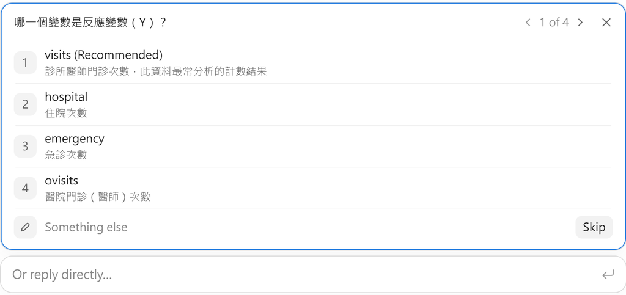

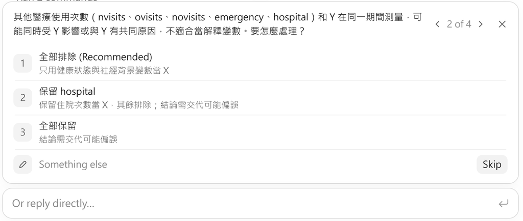

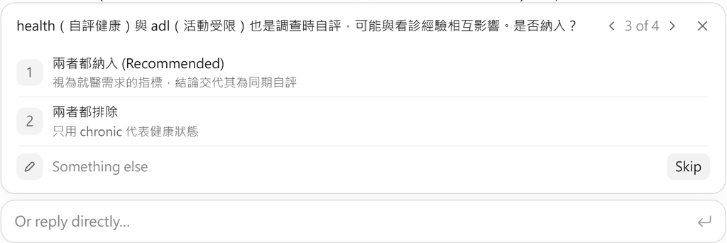

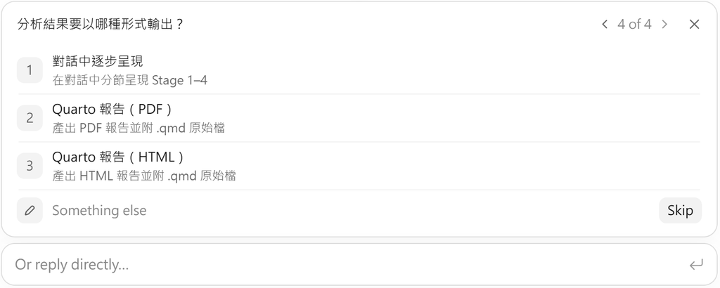

# 4 參考文獻

- Nelder, J. A., & Wedderburn, R. W. M. (1972). Generalized linear models. Journal of the Royal Statistical Society, Series A, 135(3), 370–384. https://doi.org/10.2307/2344614
- McCullagh, P., & Nelder, J. A. (1989). Generalized Linear Models (2nd ed.). Chapman & Hall.